# Lista 1 de Machine Learning - Higor David Oliveira - AM 23/2

## Questão 1

```python
# %pip install ucimlrepo
# %pip install matplotlib
# %pip install pandas
```

```python
import numpy as np
import pandas as pd
import matplotlib.pyplot as plt
```

Leitura do banco de dados

```python
data_1 = pd.read_csv('data/haberman+s+survival/haberman.data', header = None, names = ['Age', 'Year_of_operation', 'Number_of_nodes', 'Survival_status'])
data_1.head() # mostra o começo do dataset
```

|  | Age | Year_of_operation | Number_of_nodes | Survival_status |
| --- | --- | --- | --- | --- |
| 0 | 30 | 64 | 1 | 1 |
| 1 | 30 | 62 | 3 | 1 |
| 2 | 30 | 65 | 0 | 1 |
| 3 | 31 | 59 | 2 | 1 |
| 4 | 31 | 65 | 4 | 1 |

1. Age of patient at time of operation (numerical)
2. Patient's year of operation (year - 1900, numerical)
3. Number of positive axillary nodes detected (numerical)
4. Survival status (class attribute)

#### a e b) Média e mediana dos atributos para o banco de dados e para cada classe.

```python
atribute_index = np.arange(0,3)
print(f'--- Média dos atributos de todas as classes:\n {data_1.iloc[:,atribute_index].mean()}')
print(f'--- Mediana dos atributos de todas as classes:\n {data_1.iloc[:,atribute_index].median()}')
# print("Média dos atributos de todas as classes:\n", data_1.iloc[:,atribute_index].mean())
# print("Mediana dos atributos de todas as classes:\n", data_1.iloc[:,atribute_index].median())

# Separação entre classes
data_1_class1 = data_1[(data_1.Survival_status == 1)]
data_1_class2 = data_1[(data_1.Survival_status == 2)]

print(f'--- Média dos atributos da classe 1:\n {data_1_class1.iloc[:,atribute_index].mean()}')
print(f'--- Mediana dos atributos da classe 1:\n {data_1_class1.iloc[:,atribute_index].median()}')
print(f'--- Média dos atributos da classe 2:\n {data_1_class2.iloc[:,atribute_index].mean()}')
print(f'--- Mediana dos atributos da classe 2:\n {data_1_class2.iloc[:,atribute_index].median()}')
# print("Média dos atributos da classe 1:\n", data_1_class1.iloc[:,atribute_index].mean())
# print("Mediana dos atributos da classe 1:\n", data_1_class1.iloc[:,atribute_index].median())
# print("Média dos atributos da classe 2:\n", data_1_class2.iloc[:,atribute_index].mean())
# print("Mediana dos atributos da classe 2:\n", data_1_class2.iloc[:,atribute_index].median())
```

```
--- Média dos atributos de todas as classes:
 Age                  52.457516
Year_of_operation    62.852941
Number_of_nodes       4.026144
dtype: float64
--- Mediana dos atributos de todas as classes:
 Age                  52.0
Year_of_operation    63.0
Number_of_nodes       1.0
dtype: float64
--- Média dos atributos da classe 1:
 Age                  52.017778
Year_of_operation    62.862222
Number_of_nodes       2.791111
dtype: float64
--- Mediana dos atributos da classe 1:
 Age                  52.0
Year_of_operation    63.0
Number_of_nodes       0.0
dtype: float64
--- Média dos atributos da classe 2:
 Age                  53.679012
Year_of_operation    62.827160
Number_of_nodes       7.456790
dtype: float64
--- Mediana dos atributos da classe 2:
 Age                  53.0
Year_of_operation    63.0
Number_of_nodes       4.0
dtype: float64
```

#### c) Matriz de coeficientes de correlação

Para calcular a matriz de correlação, basta usarmos o método do Pandas df.corr()

```python
data_1.corr('pearson')
```

|  | Age | Year_of_operation | Number_of_nodes | Survival_status |
| --- | --- | --- | --- | --- |
| Age | 1.000000 | 0.089529 | -0.063176 | 0.067950 |
| Year_of_operation | 0.089529 | 1.000000 | -0.003764 | -0.004768 |
| Number_of_nodes | -0.063176 | -0.003764 | 1.000000 | 0.286768 |
| Survival_status | 0.067950 | -0.004768 | 0.286768 | 1.000000 |

#### d) Histograma de cada atributo

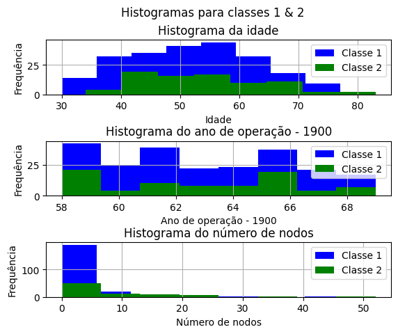

```python
fig1, axs1 = plt.subplots(3,1)
plt.suptitle("Histogramas para classes 1 & 2")
plt.subplots_adjust(hspace=0.85)
titles = ["Histograma da idade", "Histograma do ano de operação - 1900", "Histograma do número de nodos"]
xlabels = ["Idade","Ano de operação - 1900","Número de nodos"]
for i in range(0,3):
    axs1[i].hist(data_1_class1.iloc[:,i], bins=8, color="blue")
    axs1[i].hist(data_1_class2.iloc[:,i], bins=8, color="green")
    axs1[i].set_title(titles[i])
    axs1[i].set_ylabel("Frequência")
    axs1[i].set_xlabel(xlabels[i])
    axs1[i].legend(["Classe 1", "Classe 2"])
    axs1[i].grid()
```

Observando a distribuição das duas classes para cada atributo, podemos concluir que a tarefa de classificação não será fácil, pois a distribuição dos atributos está muito entre as duas classes.

Pelo histograma, ainda é possível perceber que o número de amostras não está balanceado entre as duas classes.

#### e) Gráfico 3D das amostras

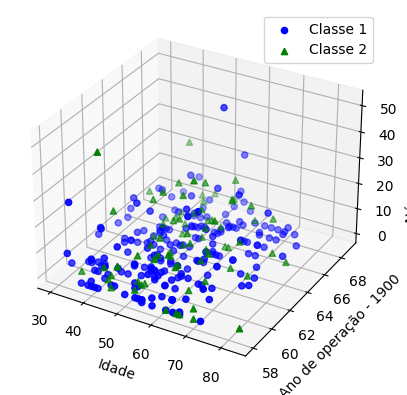

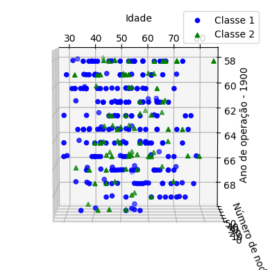

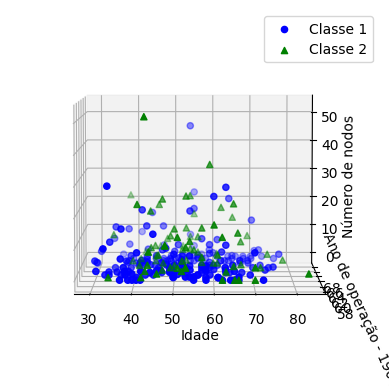

```python
fig2 = plt.figure()
ax2 = fig2.add_subplot(projection='3d')
ax2.scatter3D(list(data_1_class1.iloc[:,0]),list(data_1_class1.iloc[:,1]),list(data_1_class1.iloc[:,2]), marker='o', color='blue')
ax2.scatter3D(list(data_1_class2.iloc[:,0]),list(data_1_class2.iloc[:,1]),list(data_1_class2.iloc[:,2]), marker='^', color='green')
ax2.set_xlabel("Idade")
ax2.set_ylabel("Ano de operação - 1900")
ax2.set_zlabel("Número de nodos")
ax2.legend(["Classe 1", "Classe 2"])

fig3 = plt.figure()
ax3 = fig3.add_subplot(projection='3d')
ax3.scatter3D(list(data_1_class1.iloc[:,0]),list(data_1_class1.iloc[:,1]),list(data_1_class1.iloc[:,2]), marker='o', color='blue')
ax3.scatter3D(list(data_1_class2.iloc[:,0]),list(data_1_class2.iloc[:,1]),list(data_1_class2.iloc[:,2]), marker='^', color='green')
ax3.set_xlabel("Idade")
ax3.set_ylabel("Ano de operação - 1900")
ax3.set_zlabel("Número de nodos")
ax3.view_init(elev=-85,azim=-90)
ax3.legend(["Classe 1", "Classe 2"])

fig4 = plt.figure()
ax4 = fig4.add_subplot(projection='3d')
ax4.scatter3D(list(data_1_class1.iloc[:,0]),list(data_1_class1.iloc[:,1]),list(data_1_class1.iloc[:,2]), marker='o', color='blue')
ax4.scatter3D(list(data_1_class2.iloc[:,0]),list(data_1_class2.iloc[:,1]),list(data_1_class2.iloc[:,2]), marker='^', color='green')
ax4.set_xlabel("Idade")
ax4.set_ylabel("Ano de operação - 1900")
ax4.set_zlabel("Número de nodos")
ax4.view_init(elev=5,azim=-90)
ax4.legend(["Classe 1", "Classe 2"])
```

Analisando os gráficos plotados acima, que foram usados as 3 características do banco de dados como eixos, é possível concluir que a tarefa de classificação para diferenciar as duas classes muito dificilmente terá uma acurácia alta.

Assim também, vendo a distruibuição da frequência dos valores nos histogramas, vemos que o "formato" da distruibuição dos dados se assemelha tanto para a classe 1 quanto pra classe 2, ficando, assim, difícil fazer um limiar de separação claro entre elas.

## Questão 2

Calcule a informação mútua de cada atributo para a classe do banco de dados car evaluation.

```python
# from ucimlrepo import fetch_ucirepo # código extraido do próprio site de download do banco de dados

# fetch dataset
# car_evaluation = fetch_ucirepo(id=19)

# data (as pandas dataframes)
# data_2 = car_evaluation
# data_2_feat = car_evaluation.data.features
# data_2_targ = car_evaluation.data.targets

# # metadata
# print(car_evaluation.metadata)

# # variable information
# print(car_evaluation.variables)

data_2 = pd.read_csv('data/car+evaluation/car.data', names=['buying', 'maint', 'doors', 'persons', 'lug_boot', 'safety', 'target'])
data_2_feat = data_2.iloc[:,:-1]
data_2_targ = data_2.iloc[:,-1:]

print(data_2.head())
# print("Dados type: ", type(data_2))
# print(data_2_feat.head())
# print(data_2_targ.head())
```

```
  buying  maint doors persons lug_boot safety target
0  vhigh  vhigh     2       2    small    low  unacc
1  vhigh  vhigh     2       2    small    med  unacc
2  vhigh  vhigh     2       2    small   high  unacc
3  vhigh  vhigh     2       2      med    low  unacc
4  vhigh  vhigh     2       2      med    med  unacc
```

Informação Mútua (MI) pode ser calculada 2 a 2 usando a expressão abaixo: $$M(x_1,x_2)=H(x_1)+H(x_2)-H(x_1,x_2)$$ sendo, $H$ função entropia, dada por: $$H(x) = -\sum_{x_1}p(x_1)log_2[p(x_1)]$$
E por: $$H(x_1, x_2) = -\sum_{x_1,x_2}p(x_1,x_2)log_2[p(x_1,x_2)]$$
sendo, $p$ função probabilidade,
A probabilidade será calculada como média simples da frequência $$p(x_1 = a) = \frac{frequência(a)}{n°\ amostras\ x_1}$$ Calculando a frequência e entropia de cada dado, temos:

```python
data_2_pd = data_2_feat # Base completa
data_2_pd['target'] = data_2_targ

# Calculo da probabilidade de cada elemento da classe alvo
target_count = data_2_targ.groupby(data_2_targ.columns[-1])[data_2_targ.columns[-1]].count()
target_freq = target_count.transform(lambda x : x/target_count.sum())
for i, column in enumerate(data_2_feat.columns):
    if column == data_2_pd.columns[-1]:
        continue

    # Calculo da probabilidade de cada elemento da coluna de atributo
    column_count = data_2_feat.groupby(column)[column].count()
    column_freq = column_count.transform(lambda x : x/column_count.sum())

    # Calculo da probabilidade de cada elemento da coluna com a coluna alvo ("target" ou "class")
    column_count_target = data_2_pd.groupby(data_2_pd.columns[-1])[column].value_counts()
    column_freq_target = column_count_target.transform(lambda x : x/column_count_target.sum())

    # Calculo da informação mútua
    #Entropia do atributo
    column_entropy = -sum(column_freq*np.log2(column_freq))

    #Entropia do alvo
    target_entropy = -sum(target_freq*np.log2(target_freq))

    #Entropia 2 a 2
    column_entropy_target = -sum(column_freq_target*np.log2(column_freq_target))

    #Informação mútua
    info_mutua = column_entropy + target_entropy - column_entropy_target

    print(f'A informação mútua entre os atributos de {column} e target é de aproximadamente {info_mutua:.4f}')
    # print(f'A informação mútua entre os atributos de {column} e target é de aproximadamente {info_mutua:.4f} = {column_entropy:.4f} + {target_entropy:.4f} - {column_entropy_target:.4f}')
```

```
A informação mútua entre os atributos de buying e target é de aproximadamente 0.0964
A informação mútua entre os atributos de maint e target é de aproximadamente 0.0737
A informação mútua entre os atributos de doors e target é de aproximadamente 0.0045
A informação mútua entre os atributos de persons e target é de aproximadamente 0.2197
A informação mútua entre os atributos de lug_boot e target é de aproximadamente 0.0300
A informação mútua entre os atributos de safety e target é de aproximadamente 0.2622
```

Observando os valores obtidos, e, sendo a medida de informação mútua um indicativo de dependência entre os dados, podemos concluir que, os atributos de maior relevância para a classe são "safety" e "persons", pois possuem os maiores valores e, logo, não devem ser eliminados.

Já os atributos "lug_boot" e "doors" possuem valor de informação mútua muito pequena, logo, a variação no valor não contribue consideravelmente para a classe e assim, poderiam ser eliminados para simplificar os dados e, possivelmente, melhorar o desempenho de um classificador.

## Questão 3: Base de dados CNAE_9_reduzido

#### Letra A)

Importação dos dados

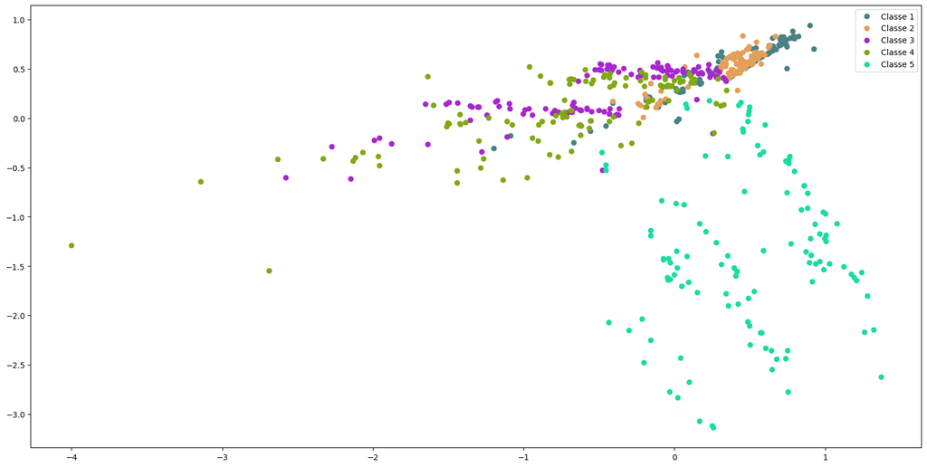

```python
data_3 = pd.read_fwf('data/CNAE_9_reduzido/CNAE_9_reduzido.txt', header = None)
data_3.describe()

data_3_target = pd.DataFrame()
data_3_target['target'] = data_3.iloc[:,0]
data_3_atribute = data_3.iloc[:,1:-1]

#Usando matriz de covariância
eigValues, eigVectors = np.linalg.eig(data_3_atribute.cov())

#Subtrair dos dados a média
data_3_normalized = data_3_atribute - data_3_atribute.mean()

#Seleciona os dois autovetores associados aos maiores autovalores
#M será a matriz de projeção dos dados
M = eigVectors[:,0:2]

#Projeta os dados nos autovetores principais
proj_data = data_3_normalized @ M

classes = data_3_target[data_3_target.columns[0]].unique()

#Plota o gráfico
plt.figure(figsize=(20,10))
legend = []
data_3_color_map_list = []
for classe in classes:
    color = np.random.uniform(0,1,3)
    data_select = proj_data[data_3_target[data_3_target.columns[0]] == classe]
    plt.plot(data_select[1],data_select[0],marker='o',linestyle='',color = color, label=classe)
    data_3_color_map_list.append(color)
    legend.append(f'Classe {classe}')
plt.legend(legend)
data_3_color_map_dict = dict(zip(classes, data_3_color_map_list))
```

#### letra B) PCA com branqueamento dos dados

Primeiro, vamos extrair a matriz de correlação entre os dados.

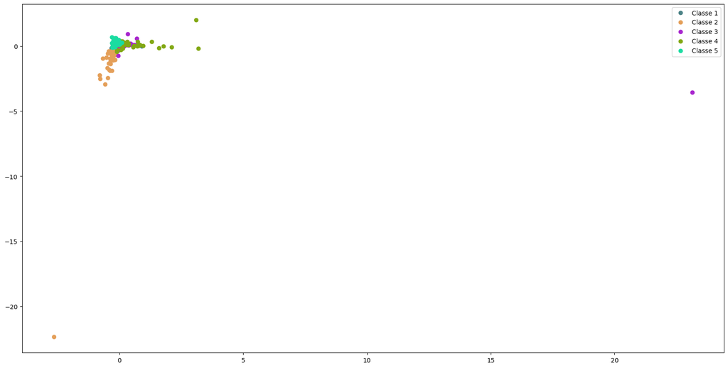

```python
#Usando matriz de coef. de correlação
eigValues_corr, eigVectors_corr = np.linalg.eig(data_3_atribute.corr())
# eigValues_cov, eigVectors_cov = np.linalg.eig(data_3_atribute.cov())

#Seleciona os dois autovetores associados aos maiores autovalores
#M será a matriz de projeção dos dados
M_full = eigVectors_corr[:,:]

# Calculando a matriz diagonal V. V é a raiz quadrada do inverso da matriz formada pelos autovalores vindos da correlação
eigVectors_corr_diag = np.diag(eigValues_corr)

data_3_normalized_centralized = (data_3_atribute - data_3_atribute.mean())/data_3_atribute.std()
# data_3_normalized_centralized = (data_3_atribute - data_3_atribute.mean())

# Para matrizes diagonais, a raiz quadrada é calculada como raiz quadrada dos elementos centrais
V = np.linalg.inv(eigVectors_corr_diag)
V = np.apply_along_axis(np.sqrt, 0, V)

# Calcula a matriz de projeção MV
MV = M_full @ V.T
# MV = MV[:,0:2] # Não é necessário, mas simplifica calculos

# #Projeta os dados na matriz de branqueamento
proj_data_branc = data_3_normalized_centralized @ MV

# #Plota o gráfico
plt.figure(figsize=(20,10))
for classe in classes:
    color = data_3_color_map_dict[classe]
    data_select = proj_data_branc[data_3_target[data_3_target.columns[-1]] == classe]
    plt.plot(data_select[data_select.columns[0]],data_select[data_select.columns[1]],marker='o',linestyle='',color = color, label=classe)
plt.legend(legend)

# Existem 2 atributos que fogem do padrão do restante e são plotados distante, reduzindo o zoom do plot. Reacertando o zoom
# plt.xlim([-2, 4])
# plt.ylim([-4, 3])
```

A técnica de branqueamento dos dados faz com que os dados se tornem descorrelacionado. A descorrelação faz com que os atributos de cada classe se projetem sobre eixos (componentes principais) com maior distinção.

No nosso banco de dados, é possível ver que a descorrelação possibilitou separar melhor os atributos de algumas classes, como para as classes 3 e 2, porém, isso não aconteceu para todas as classes. Para demais classes, os atributos se projetam muito próximos, dificultando o trabalho de classificação por distância, por exemplo.

#### Letra C) TSNE

[output not shown]

[output cut: 50 more lines]

[output not shown]

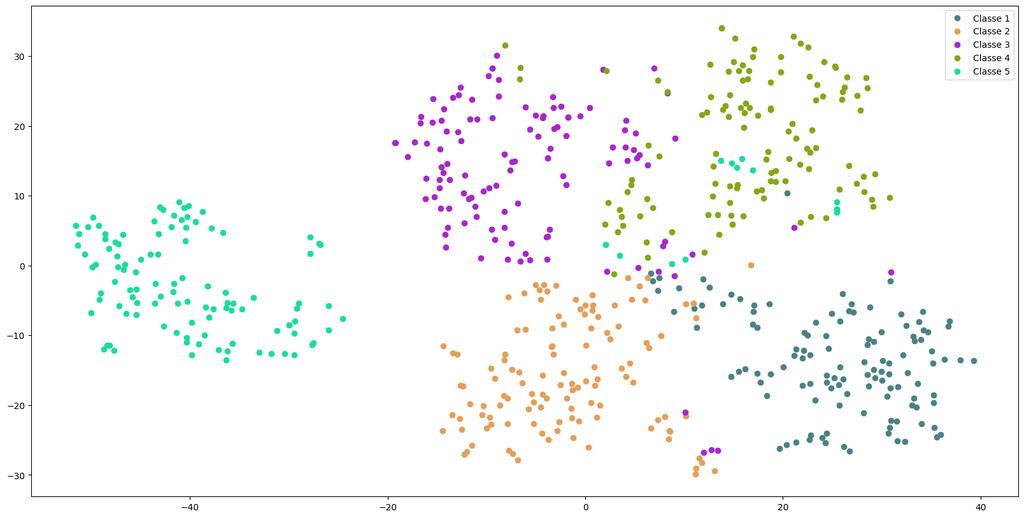

```python
import tsne_python.tsne as tsne # tsne library under tsne_python\tsne.py

data_3_numpy = data_3_atribute.to_numpy()
data_3_tsne_output = tsne.tsne(data_3_numpy)

data_3_tsne_output_df = pd.DataFrame(data_3_tsne_output, columns=['x','y'])
data_3_tsne_output_df['target'] = data_3_target[data_3_target.columns[0]]

#Plota o gráfico
plt.figure(figsize=(20,10))
for classe in classes:
    color = data_3_color_map_dict[classe]
    data_select = data_3_tsne_output_df.loc[data_3_tsne_output_df[data_3_tsne_output_df.columns[-1]] == classe]
    plt.plot(data_select[data_select.columns[0]],data_select[data_select.columns[1]],marker='o',linestyle='',color = color, label=classe)
plt.legend(legend)
```

#### Questão D)

Primeiro, definindo as funções de auxílio para os algoritmos:

```python
def distancia_pw2(pt1, pt2):
    # Parameter assertion
    if pt1 is None or pt2 is None:
        print("Empty input parameter for distance", pt1, pt2)
        return
    # if not isinstance(pt1, np.ndarray) or not isinstance(pt2, np.ndarray):
    #     print(f"Wrong input data type. Expected {np.ndarray} got {type(pt1)},{type(pt2)}")
    #     return

    dist = np.sum((pt1 - pt2)**2,axis=1)  # distancia^2
    return dist

def knn_predict(x_train: pd.DataFrame, y_train: pd.DataFrame, x_test: pd.DataFrame, classes, k=1):
    y_predict = []

    # Convertendo para numpy para otimizar
    x_train = x_train.to_numpy()
    x_test = x_test.to_numpy()

    for i, pt in enumerate(x_test):
        # Calcula distância com todos os elementos
        dist_vet = distancia_pw2(pt, x_train)
        if dist_vet is None:
            print("None distance dataframe")
            return

        # Ordena (pega somente os indices)
        order_up_indexes = np.argsort(dist_vet)
        # Pega os indices dos menores
        nearest_classes = y_train.iloc[order_up_indexes[0:k],0]

        # Levanta a frequencia de cada classe
        class_count = np.zeros(classes.shape[0], dtype=np.uint64)
        for classe in nearest_classes:
            class_elements = np.where(classes == classe)
            class_elements = np.squeeze(np.array(class_elements))
            class_count[class_elements] = class_count[class_elements] + 1
        y_predict.append(classes[np.argmax(class_count)])

    return np.array(y_predict)

def knn_accuracy(y_predict: np.ndarray, y_gnd_truth: np.ndarray):
    NC = np.count_nonzero(y_predict == y_gnd_truth)
    return NC/y_gnd_truth.shape[0]

def knn_recall(y_predict: np.ndarray, y_gnd_truth: np.ndarray):
    VP = np.count_nonzero(np.logical_and(y_predict == 1, y_predict == y_gnd_truth))
    FN = np.count_nonzero(np.logical_and(y_predict == 0, y_predict != y_gnd_truth))
    if VP + FN == 0:
        return 0
    return VP / (VP + FN)

def knn_precision(y_predict: np.ndarray, y_gnd_truth: np.ndarray):
    VP = np.count_nonzero(np.logical_and(y_predict == 1, y_predict == y_gnd_truth))
    FP = np.count_nonzero(np.logical_and(y_predict == 1, y_predict != y_gnd_truth))
    if VP + FP == 0:
        return 0
    return VP / (VP + FP)
```

Usando o modelo de NN e calculando sua acurácia, temos:

```python
# Separando os sets - hold out
data_3_train = data_3_atribute.iloc[0:480, :]
data_3_train_class = data_3_target.iloc[0:480, :]
# print(data_3_train)
data_3_test = data_3_atribute.iloc[480:-1, :].reset_index(drop=True)
data_3_test_class = data_3_target.iloc[480:-1, :].reset_index(drop=True)
# print(data_3_test)

y_predict = knn_predict(data_3_train, data_3_train_class, data_3_test, classes)
print(f'Previsões: \n{y_predict}')
y_knn_acc = knn_accuracy(y_predict, data_3_test_class[data_3_test_class.columns[0]].to_numpy())
print(f'A acurácia do NN foi de {y_knn_acc*100:.2f} %')
```

```
Previsões:
[1 2 3 4 5 1 2 3 4 5 1 2 3 4 5 1 2 3 4 5 1 2 3 4 5 1 2 3 4 5 1 2 3 4 5 1 2
 2 4 5 1 2 3 3 5 1 2 3 4 5 1 2 3 4 5 1 2 3 4 5 1 2 5 4 5 1 2 3 4 5 1 2 3 4
 5 1 2 3 4 5 1 2 3 4 5 1 2 3 4 5 1 2 3 4 5 1 2 3 4 5 1 2 3 4 5 1 2 3 4 5 1
 2 3 4 5 1 2 3 4]
A acurácia do NN foi de 97.48 %
```

Analisando o valor alto de acurácia acima (97,48%), temos um indicativo que as distâncias entre as amostras é bem definida, possívelmente com as amostras afastadas entre amostras de cada classe. Considerando isso e os gráficos dos blocos anteriores, o gráfico que representa melhor as distâncias seriam os plotados na C), ou seja, o do TSNE.

#### Questão 4: Base de dados Breast Cancer Wisconsin (Diagnostic)

Primeiro importando os dados

```python
# fetch dataset
breast_cancer_wisconsin_diagnostic = fetch_ucirepo(id=17)

# data (as pandas dataframes)
data_4 = breast_cancer_wisconsin_diagnostic
data_4_atribute = breast_cancer_wisconsin_diagnostic.data.features
data_4_target = breast_cancer_wisconsin_diagnostic.data.targets

# metadata
print(breast_cancer_wisconsin_diagnostic.metadata)

# variable information
# print(breast_cancer_wisconsin_diagnostic.variables)

# print(f'A lista de colunas é:\n{list(data_4_atribute.columns)}')
print(data_4_atribute.head())
```

[output not shown]

Como preparação dos dados, vemos que o banco de dados não possui valores faltando. Assim também, ja se separou removendo a classe da tabela de atributos, para evitar ser usado como atributo durante o treino dos modelos. Como o import foi feito pelo framework ucirepo, também ja foi removido qualquer identificador de index na lista, mas se esse estivesse presente como coluna, seria necessário remover.

Além disso, observando os valores (todos númericos), vemos que a escala entre eles é diferente: enquanto há atributos variando entre 0 e 1, existem outros que são >900. A normalização e centralização, feita pelo PCA na questão B, provavelmente se mostrará útil em melhorar a classificação.

A) Aplicando no knn

```python
# Separando os sets - hold out para as 300 primeiras para treino e o restante para teste
data_4_train = data_4_atribute.iloc[0:300, :]
data_4_train_class = data_4_target.iloc[0:300, :]
# print(data_4_train)
data_4_test = data_4_atribute.iloc[300:-1, :].reset_index(drop=True)
data_4_test_class = data_4_target.iloc[300:-1, :].reset_index(drop=True)
# print(data_4_test)
data_4_classes = data_4_target[data_4_target.columns[0]].unique()

y_predict = knn_predict(data_4_train, data_4_train_class, data_4_test, data_4_classes)
print(f'Previsões: \n{y_predict}')
y_knn_acc = knn_accuracy(y_predict, data_4_test_class[data_4_test_class.columns[0]].to_numpy())
print(f'A acurácia do NN foi de {y_knn_acc*100:.2f} %')
```

```
Previsões:
['M' 'B' 'M' 'B' 'B' 'B' 'B' 'B' 'B' 'B' 'B' 'M' 'B' 'B' 'B' 'B' 'B' 'M'
 'B' 'B' 'B' 'M' 'B' 'M' 'B' 'B' 'B' 'B' 'M' 'M' 'M' 'B' 'B' 'B' 'B' 'M'
 'B' 'M' 'B' 'M' 'B' 'B' 'B' 'M' 'B' 'B' 'B' 'B' 'B' 'B' 'B' 'B' 'M' 'M'
 'B' 'B' 'B' 'M' 'B' 'B' 'B' 'B' 'B' 'M' 'B' 'M' 'M' 'B' 'M' 'M' 'M' 'M'
 'M' 'M' 'B' 'M' 'B' 'B' 'B' 'M' 'B' 'B' 'B' 'B' 'B' 'B' 'B' 'M' 'B' 'M'
 'B' 'B' 'M' 'M' 'B' 'B' 'B' 'B' 'B' 'B' 'M' 'B' 'B' 'B' 'B' 'B' 'B' 'M'
 'M' 'B' 'B' 'B' 'B' 'M' 'M' 'B' 'B' 'M' 'B' 'B' 'B' 'B' 'B' 'B' 'B' 'B'
 'B' 'B' 'B' 'B' 'B' 'B' 'M' 'M' 'B' 'M' 'B' 'M' 'M' 'B' 'B' 'M' 'B' 'B'
 'M' 'B' 'M' 'B' 'M' 'M' 'B' 'M' 'B' 'B' 'B' 'B' 'B' 'B' 'B' 'B' 'M' 'M'
 'B' 'B' 'B' 'M' 'B' 'B' 'M' 'B' 'B' 'M' 'M' 'B' 'B' 'B' 'M' 'B' 'B' 'M'
 'B' 'M' 'B' 'B' 'M' 'B' 'M' 'M' 'B' 'B' 'B' 'M' 'M' 'B' 'B' 'B' 'B' 'B'
 'M' 'M' 'M' 'M' 'B' 'M' 'B' 'B' 'B' 'B' 'M' 'B' 'B' 'B' 'B' 'B' 'M' 'B'
 'M' 'M' 'B' 'B' 'B' 'M' 'B' 'B' 'B' 'B' 'B' 'B' 'B' 'B' 'B' 'B' 'M' 'M'
 'B' 'M' 'B' 'B' 'B' 'B' 'B' 'B' 'B' 'B' 'B' 'B' 'B' 'B' 'B' 'M' 'B' 'B'
 'B' 'B' 'B' 'B' 'B' 'B' 'B' 'B' 'B' 'B' 'B' 'M' 'M' 'M' 'M' 'M']
A acurácia do NN foi de 88.43 %
```

```python
#Usando matriz de covariância
data_4_eigValues, data_4_eigVectors = np.linalg.eig(data_4_atribute.corr())

#Subtrair dos dados a média e normalizar
data_4_normalized = (data_4_atribute - data_4_atribute.mean())/data_4_atribute.std()

#Seleciona os dois autovetores associados aos maiores autovalores
#M será a matriz de projeção dos dados
data_4_eigVectors = np.squeeze(data_4_eigVectors)

M = data_4_eigVectors[:,np.where(data_4_eigValues > 1)]
M = np.squeeze(M)

#Projeta os dados nos autovetores principais
data_4_proj_data = data_4_normalized @ M

print(data_4_proj_data)

print(f'Foram selecionados {M.shape[1]} de {data_4_eigVectors.shape[1]} atributos usando o critério de fisher.')
```

```
             0          1         2         3         4         5
0     9.184755   1.946870 -1.122179  3.630536  1.194059  1.410184
1     2.385703  -3.764859 -0.528827  1.117281 -0.621228  0.028631
2     5.728855  -1.074229 -0.551263  0.911281  0.176930  0.540976
3     7.116691  10.266556 -3.229948  0.152413  2.958275  3.050737
4     3.931842  -1.946359  1.388545  2.938054 -0.546267 -1.225416
..         ...        ...       ...       ...       ...       ...
564   6.433655  -3.573673  2.457324  1.176279  0.074759 -2.373105
565   3.790048  -3.580897  2.086640 -2.503825  0.510274 -0.246493
566   1.255075  -1.900624  0.562236 -2.087390 -1.808400 -0.533977
567  10.365673   1.670540 -1.875379 -2.353960  0.033712  0.567437
568  -5.470430  -0.670047  1.489133 -2.297136  0.184541  1.616415

[569 rows x 6 columns]
Foram selecionados 6 de 30 atributos usando o critério de fisher.
```

Aplicando NN sobre os dados do PCA

```python
# Separando os sets - hold out
data_4_train_2 = data_4_proj_data.iloc[0:300, :]
data_4_train_2_class = data_4_target.iloc[0:300, :]
# print(data_4_train_2)
data_4_test_2 = data_4_proj_data.iloc[300:-1, :].reset_index(drop=True)
data_4_test_2_class = data_4_target.iloc[300:-1, :].reset_index(drop=True)
# print(data_4_test_2)
data_4_classes = data_4_target[data_4_target.columns[0]].unique()

y_predict = knn_predict(data_4_train_2, data_4_train_2_class, data_4_test_2, data_4_classes)
print(f'Previsões: \n{y_predict}')
y_knn_acc = knn_accuracy(y_predict, data_4_test_2_class[data_4_test_2_class.columns[0]].to_numpy())
print(f'A acurácia do NN foi de {y_knn_acc*100:.2f}%')
```

```
Previsões:
['M' 'B' 'M' 'B' 'B' 'B' 'B' 'B' 'B' 'B' 'B' 'B' 'B' 'B' 'B' 'B' 'B' 'M'
 'B' 'B' 'B' 'M' 'B' 'M' 'B' 'B' 'B' 'B' 'M' 'M' 'M' 'B' 'B' 'B' 'B' 'M'
 'B' 'M' 'B' 'M' 'M' 'B' 'B' 'M' 'B' 'B' 'B' 'B' 'B' 'B' 'B' 'M' 'M' 'M'
 'B' 'B' 'B' 'B' 'B' 'B' 'B' 'B' 'B' 'M' 'B' 'M' 'M' 'B' 'M' 'M' 'M' 'B'
 'M' 'M' 'B' 'M' 'B' 'B' 'B' 'M' 'B' 'B' 'B' 'B' 'B' 'M' 'B' 'B' 'B' 'M'
 'B' 'B' 'M' 'M' 'B' 'B' 'B' 'B' 'B' 'B' 'M' 'B' 'B' 'B' 'B' 'B' 'B' 'B'
 'M' 'B' 'M' 'B' 'B' 'B' 'B' 'B' 'B' 'M' 'B' 'B' 'B' 'B' 'B' 'B' 'B' 'B'
 'B' 'M' 'B' 'B' 'M' 'B' 'M' 'M' 'B' 'M' 'B' 'B' 'B' 'B' 'B' 'M' 'B' 'B'
 'M' 'B' 'M' 'B' 'B' 'M' 'B' 'M' 'M' 'B' 'B' 'B' 'B' 'B' 'B' 'B' 'M' 'M'
 'B' 'B' 'B' 'B' 'B' 'B' 'M' 'M' 'B' 'B' 'B' 'B' 'B' 'B' 'B' 'B' 'B' 'M'
 'B' 'B' 'B' 'B' 'M' 'B' 'B' 'M' 'B' 'M' 'B' 'B' 'M' 'B' 'B' 'B' 'M' 'B'
 'M' 'M' 'B' 'M' 'B' 'M' 'M' 'B' 'B' 'B' 'B' 'M' 'B' 'B' 'M' 'B' 'M' 'B'
 'M' 'M' 'B' 'B' 'B' 'M' 'B' 'B' 'B' 'B' 'M' 'B' 'B' 'B' 'B' 'B' 'B' 'M'
 'B' 'M' 'M' 'M' 'B' 'B' 'B' 'M' 'B' 'B' 'B' 'B' 'B' 'B' 'B' 'B' 'B' 'B'
 'B' 'B' 'M' 'B' 'B' 'B' 'B' 'B' 'M' 'B' 'M' 'M' 'M' 'M' 'M' 'M']
A acurácia do NN foi de 94.03%
```

Acima vemos que após aplicar o PCA, o modelo de NN apresentou um resultado bem melhor em comparação com o desempenho do NN sem nenhum processamento dos dados, sendo que ainda foi selecionando somente parte da informação dos atributos.

A ganha no desempenho provavelmente está relacionada as transformações que o PCA tem sobre os dados: de normalizar e centralizar.

C) Aplicando agora o descriminante de fisher para duas classes (M, B)

```python
# Primeiro separando entre as classes, para achar S
data_4_atribute_class_1 = data_4_atribute.loc[data_4_target[data_4_target.columns[0]] == data_4_target[data_4_target.columns[0]].unique()[0]]
data_4_atribute_class_2 = data_4_atribute.loc[data_4_target[data_4_target.columns[0]] == data_4_target[data_4_target.columns[0]].unique()[1]]

# Calculando S1 e S2 e, enfim, a matriz de projeção, Sw
S1 = (data_4_atribute_class_1.shape[0] - 1)*data_4_atribute_class_1.cov()
S2 = (data_4_atribute_class_2.shape[0] - 1)*data_4_atribute_class_2.cov()
# print(S1)

Sw = S1 + S2
Sw_proj = np.linalg.inv(Sw)
# print(Sw_proj)

# Selecionando n-1 atributos projetados
V = Sw_proj @ (data_4_atribute_class_1.mean() - data_4_atribute_class_2.mean())
# print(V)

data_4_atribute_fisher_proj = data_4_atribute @ V
# Convertendo tipo de pandas Series para pandas DataFrame
data_4_atribute_fisher_proj = data_4_atribute_fisher_proj.to_frame()

print(f'Formato de saída dos dados: {data_4_atribute_fisher_proj.shape}')
print(type(data_4_atribute_fisher_proj))
```

```
Formato de saída dos dados: (569, 1)
<class 'pandas.core.frame.DataFrame'>
```

Consideramos que o fisher foi corretamente aplicado uma vez que reduziu a dimensionalidade dos dados para 1 dimensão (569 amostras x 1 dimensão), por meio de uma projeção.

Aplicando o NN sobre os dados projetados

```python
# Separando os sets - hold out
data_4_train_3 = data_4_atribute_fisher_proj.iloc[0:300]
data_4_train_3_class = data_4_target.iloc[0:300, :]
# print(data_4_train_3)
data_4_test_3 = data_4_atribute_fisher_proj.iloc[300:-1].reset_index(drop=True)
data_4_test_3_class = data_4_target.iloc[300:-1, :].reset_index(drop=True)
# print(data_4_test_3)
data_4_classes = data_4_target[data_4_target.columns[0]].unique()

y_predict = knn_predict(data_4_train_3, data_4_train_3_class, data_4_test_3, data_4_classes)
print(f'Previsões: \n{y_predict}')
y_knn_acc = knn_accuracy(y_predict, data_4_test_3_class[data_4_test_3_class.columns[0]].to_numpy())
print(f'A acurácia do NN foi de {y_knn_acc*100:.2f}%')
```

```
Previsões:
['M' 'B' 'M' 'B' 'B' 'B' 'B' 'B' 'B' 'B' 'B' 'B' 'B' 'B' 'B' 'B' 'B' 'M'
 'B' 'B' 'B' 'M' 'B' 'M' 'B' 'B' 'B' 'B' 'M' 'M' 'M' 'B' 'B' 'B' 'B' 'M'
 'B' 'M' 'B' 'M' 'B' 'B' 'B' 'M' 'B' 'B' 'B' 'M' 'B' 'B' 'B' 'M' 'M' 'M'
 'B' 'B' 'B' 'B' 'B' 'B' 'B' 'B' 'B' 'M' 'B' 'M' 'M' 'B' 'M' 'M' 'M' 'B'
 'M' 'M' 'B' 'B' 'B' 'M' 'B' 'M' 'B' 'B' 'B' 'B' 'B' 'M' 'B' 'B' 'B' 'M'
 'B' 'B' 'M' 'M' 'B' 'B' 'B' 'B' 'B' 'B' 'M' 'B' 'B' 'B' 'B' 'B' 'B' 'B'
 'M' 'B' 'B' 'B' 'B' 'M' 'M' 'B' 'B' 'M' 'B' 'B' 'B' 'B' 'B' 'M' 'B' 'B'
 'B' 'B' 'B' 'B' 'M' 'B' 'M' 'M' 'B' 'M' 'B' 'B' 'B' 'B' 'B' 'M' 'B' 'B'
 'M' 'M' 'M' 'B' 'B' 'M' 'B' 'M' 'B' 'M' 'B' 'B' 'M' 'B' 'B' 'B' 'M' 'M'
 'B' 'B' 'B' 'B' 'B' 'B' 'M' 'B' 'B' 'B' 'B' 'B' 'B' 'B' 'B' 'B' 'B' 'M'
 'B' 'B' 'B' 'B' 'B' 'B' 'B' 'M' 'B' 'M' 'B' 'B' 'M' 'B' 'B' 'B' 'B' 'B'
 'M' 'M' 'B' 'M' 'B' 'M' 'B' 'B' 'B' 'B' 'B' 'M' 'B' 'B' 'M' 'B' 'B' 'B'
 'M' 'M' 'B' 'B' 'B' 'M' 'B' 'B' 'B' 'B' 'B' 'B' 'B' 'B' 'B' 'B' 'B' 'M'
 'B' 'M' 'M' 'B' 'B' 'B' 'B' 'M' 'B' 'B' 'B' 'B' 'B' 'B' 'B' 'B' 'B' 'B'
 'B' 'B' 'B' 'B' 'B' 'B' 'B' 'B' 'B' 'B' 'M' 'M' 'M' 'M' 'M' 'M']
A acurácia do NN foi de 96.27%
```

A acurácia do classificador NN sobre os dados aplicado o discriminante do fisher foi maior, como visto acima.

A melhora no desempenho usando o discriminante de fisher é um indicativo de que os atributos nesse banco de dados tem distribuições lineares bem definidas, com variancia uniforme e com coeficientes lineares constantes e distintos entre classes, uma vez que o fisher se baseia em projeção sobre uma reta, tentando maximar a distância entre os centroides projetados de cada classe.

O bom desempenho do PCA também é um indicativo de os dados possuem distribuição linear bem definida, isto é, dados com variancia uniforme, mas não necessariamente com coeficientes lineares constantes uma vez que o PCA calcula a distância dos dados sobre uma componente linear entre os atributos.

#### Questão 7) Diagrama de Voronoi

##### A) Distância euclidiana

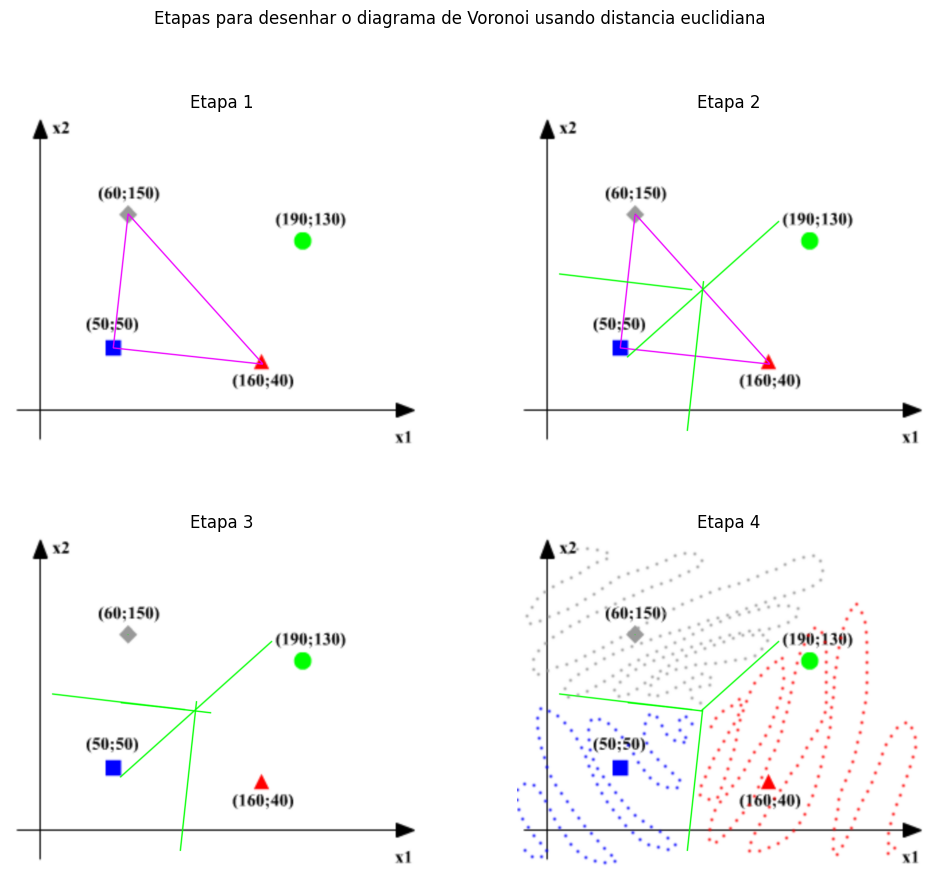

```python
etapa_1 = plt.imread('data/questao_5/step1_euclidiana_2.png')
etapa_2 = plt.imread('data/questao_5/step2_euclidiana_2.png')
etapa_3 = plt.imread('data/questao_5/step3_euclidiana_2.png')
etapa_4 = plt.imread('data/questao_5/step4_euclidiana_2.png')

fig2, axs2 = plt.subplots(2,2, figsize=(12,10))
plt.suptitle("Etapas para desenhar o diagrama de Voronoi usando distancia euclidiana")
titles = ["Etapa 1", "Etapa 2", "Etapa 3", "Etapa 4"]
figures = [etapa_1, etapa_2, etapa_3, etapa_4]
i = 0
j = 0
for figure, title in zip(figures, titles):
    # print(f'{j},{i%2}')
    axs2[j, i%2].imshow(figure)
    axs2[j, i%2].axis('off')
    axs2[j, i%2].set_title(title)
    if i >= 1:
        j = 1
    i = i + 1
```

Para o diagrama de Voronoi usando distância euclidiana basta fazer:

- Traçar a linha equidistante entre as amostras mais próximas:
  - Traçar uma linha entre as amostras (etapa 1)
  - Traçar uma mediatriz nesta linha, a mediatriz é a linha equidistante (etapa 2)
- Extender a reta até um pouco depois do cruzamento com outra e apagar as linhas entre amostras (etapa 3)
- Analisar e resolvemos os encontros das linhas equidistantes, terminando uma no encontro da outra (etapa 4)
- Resolvendo cada encontro, fechamos o poligono (ou as faces) que definem as zonas no diagrama de Voronoi (etapa 4)

B) Usando distância de cossenos

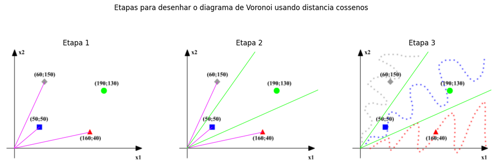

```python
etapa_1_cos = plt.imread('data/questao_5/step1_cosseno_2.png')
etapa_2_cos = plt.imread('data/questao_5/step2_cosseno_2.png')
etapa_3_cos = plt.imread('data/questao_5/step3_cosseno_2.png')
# etapa_4_cos = plt.imread('data/questao_5/step4_cosseno.png')

fig3, axs3 = plt.subplots(1,3, figsize=(15,5))
plt.suptitle("Etapas para desenhar o diagrama de Voronoi usando distancia cossenos")
titles_cos = ["Etapa 1", "Etapa 2", "Etapa 3"]
figures_cos = [etapa_1_cos, etapa_2_cos, etapa_3_cos]
i = 0
j = 0
for figure, title in zip(figures_cos, titles_cos):
    # print(f'{j},{i%2}')
    axs3[i].imshow(figure)
    axs3[i].axis('off')
    axs3[i].set_title(title)
    if i >= 1:
        j = 1
    i = i + 1
```

Similarmente, usando distância de cossenos basta fazer:

- Traçar a bissetriz entre as amostras mais próximas:
  - Traçar uma linha entre a origem e a amostra (etapa 1)
  - Traçar a bissetriz dos angulos encontrados entre as amostras (etapa 2)
- Analisar as bissetrizes, apagar as linhas entre origem e amostra, definir as zonas (etapa 3)

C) Classificando o circulo usando NN com distância euclidiana e de cossenos

Com o diagrama de Voronoi desenhado acima, podemos facilmente usar as figuras acima para classificar a amostra circulo. Para distância euclidiana, o circulo seria atribuido a classe triângulo Para distância de cossenos, o circulo seria atribuido a classe quadrado

#### Questão 8)

Primeiro, importando os dados

```python
data_5 = pd.read_csv('data/htru2/HTRU_2.csv', header = None)
print(data_5.head()) # mostra o começo do dataset

data_5_atribute = data_5[data_5.columns[:]]
data_5_atribute = data_5_atribute.drop(columns=data_5_atribute.columns[-1])
data_5_target = data_5[data_5.columns[-1]].to_frame()

data_5_classes = data_5_target[data_5_target.columns[0]].unique()
```

```
            0          1         2         3         4          5          6  \
0  140.562500  55.683782 -0.234571 -0.699648  3.199833  19.110426   7.975532
1  102.507812  58.882430  0.465318 -0.515088  1.677258  14.860146  10.576487
2  103.015625  39.341649  0.323328  1.051164  3.121237  21.744669   7.735822
3  136.750000  57.178449 -0.068415 -0.636238  3.642977  20.959280   6.896499
4   88.726562  40.672225  0.600866  1.123492  1.178930  11.468720  14.269573

            7  8
0   74.242225  0
1  127.393580  0
2   63.171909  0
3   53.593661  0
4  252.567306  0
```

##### Letra A) Usando distância Mahalanobis

Primeiro definido a função de knn usando agora a distância de Mahalanobis

```python
def distancia_Mahalanobis_pw2(pt1, pt2, cov_matrix):
    # Parameter assertion
    if pt1 is None or pt2 is None or cov_matrix is None:
        print("Empty input parameter for distance", pt1, pt2, type(cov_matrix))
        return None

    diff = pt1 - pt2 # calcula (a-b)
    dist = np.transpose(diff) @ cov_matrix @ diff
    return dist

def rocchio_predict_Mahalanobis(x_train: pd.DataFrame, y_train: pd.DataFrame, x_test: pd.DataFrame, classes):
    # Calculo dos centroidas
    centroids = []
    for classe in classes:
        attributes_class = x_train.loc[y_train[y_train.columns[0]] == classe]
        attributes_class = attributes_class.reset_index(drop=True)
        centroid = attributes_class.mean(axis=0).to_numpy()
        centroids.append(centroid)

    # Preparação da matriz covariancia inversa transposta
    cov_matrix_t = np.linalg.inv(x_train.cov()).transpose()
    y_predict = []
    for i, pta in x_test.iterrows():
        dist_vet = []
        for centroid in centroids:
            dist_vet.append(distancia_Mahalanobis_pw2(pt1=pta.to_numpy(), pt2=centroid, cov_matrix=cov_matrix_t))

        if dist_vet is None:
            print("None distance dataframe")
            return
        for dist in dist_vet:
            if dist == np.nan:
                print('Nan distance')
            break

        # Ordena o vetor de distâncias e pega os índices da ordem
        order_up_indexes = np.argsort(dist_vet)
        # Pega a classe de menor distância
        y_predict.append(classes[order_up_indexes[0]])
    return np.array(y_predict)
```

Aplicando o modelo definido de rocchio

```python
rocchio_acc_score = []
rocchio_recall_score = []
rocchio_precision_score = []
rocchio_y_predict = []
roccio_tempos = []
roccio_tempos.append(time.time())
for i in range(0,5):
    # Dividindo os dados (hold out, 70/30)
    # Train - 70%
    data_5_atribute_train = data_5_atribute.sample(frac=0.7)
    data_5_target_train = data_5_target.iloc[data_5_atribute_train.index]
    # Test - 30%
    data_5_atribute_test = data_5_atribute.drop(data_5_atribute_train.index)
    data_5_target_test = data_5_target.iloc[data_5_atribute_test.index]

    # Resetando indexes para começar em 0
    data_5_atribute_train = data_5_atribute_train.reset_index(drop=True)
    data_5_target_train = data_5_target_train.reset_index(drop=True)
    data_5_atribute_test = data_5_atribute_test.reset_index(drop=True)
    data_5_target_test = data_5_target_test.reset_index(drop=True)

    # Aplicando modelo classificação
    rocchio_y_predict.append(rocchio_predict_Mahalanobis(data_5_atribute_train, data_5_target_train, data_5_atribute_test, data_5_classes))

    # Transformando o dataframe de classificação do test para np array
    rocchio_y_gnd_truth = data_5_target_test[data_5_target_test.columns[0]].to_numpy()

    # Calculando métricas
    rocchio_acc_score.append(knn_accuracy(rocchio_y_predict[-1], rocchio_y_gnd_truth))
    rocchio_precision_score.append(knn_precision(rocchio_y_predict[-1], rocchio_y_gnd_truth))
    rocchio_recall_score.append(knn_recall(rocchio_y_predict[-1], rocchio_y_gnd_truth))
    roccio_tempos.append(time.time())
for acc, precision, recall in zip (rocchio_acc_score, rocchio_precision_score, rocchio_recall_score):
    print(f'Accuracy:{acc*100:.2f}% Precision:{precision*100:.2f}% Recall:{recall*100:.2f}%')

print(f'-------------\nMédias Acurracy: {np.mean(rocchio_acc_score)*100:.2f}% Precision: {np.mean(rocchio_precision_score)*100:.2f}% Recall: {np.mean(rocchio_recall_score)*100:.2f}%')
print(f'Tempo total = {(roccio_tempos[-1] - roccio_tempos[0]):.2f}s. Tempo médio: {sum([(y - x) for x,y in zip(roccio_tempos,roccio_tempos[1:])])/len([(y - x) for x,y in zip(roccio_tempos,roccio_tempos[1:])]):.2f}s')
# tempos_segundos_temp = [(y - x) for x,y in zip(roccio_tempos,roccio_tempos[1:])]
# print(f'Tempo médio: {sum(tempos_segundos_temp)/len(tempos_segundos_temp):.2f}s')
```

```
Accuracy:97.86% Precision:93.10% Recall:81.97%
Accuracy:97.78% Precision:93.76% Recall:80.79%
Accuracy:97.67% Precision:92.99% Recall:80.73%
Accuracy:97.99% Precision:93.67% Recall:83.81%
Accuracy:97.80% Precision:92.91% Recall:81.70%
-------------
Médias Acurracy:97.82% Precision:93.28% Recall:81.80%
Tempo total = 3.18s. Tempo médio: 0.64s
```

Como podemos ver, os valores de acurácia, precisão e recall foram altos para o modelo de Rocchio usando distancia de mahalanobis. Assim também, o tempo de execução foi bem baixo, o que é esperado do método de Rocchio, que só precisa comparar a distância do atributo com o centroid de cada classe (que são somente 2, no caso).

##### Letra B) Knn, hold-out (70/30) com validação usando parte do set de treino (35/35 validação)

```python
knn_acc_score = []
knn_recall_score = []
knn_precision_score = []
k_best = []
tempos_best = []
y_predict_best = []
y_gnd_truth_best = []
tempo_start = time.time()
for i in range(0,5):
    # Dividindo os dados (hold out, 70/30)
    # Train - 70%
    data_5_atribute_train = data_5_atribute.sample(frac=0.7)
    data_5_target_train = data_5_target.iloc[data_5_atribute_train.index]
    # Test - 30%
    data_5_atribute_test = data_5_atribute.drop(data_5_atribute_train.index)
    data_5_target_test = data_5_target.iloc[data_5_atribute_test.index]

    # Resetando indexes para começar em 0
    data_5_atribute_train = data_5_atribute_train.reset_index(drop=True)
    data_5_target_train = data_5_target_train.reset_index(drop=True)
    data_5_atribute_test = data_5_atribute_test.reset_index(drop=True)
    data_5_target_test = data_5_target_test.reset_index(drop=True)

    # Dividindo o set de treinamento para validação para achar o melhor k dado o conjunto
    # Validação 50%
    data_5_atribute_train_validation = data_5_atribute_train.sample(frac=0.5)
    data_5_target_train_validation = data_5_target_train.iloc[data_5_atribute_train_validation.index]

    # Teste #2 50%
    data_5_atribute_train_train = data_5_atribute_train.drop(data_5_atribute_train_validation.index)
    data_5_target_train_train = data_5_target.iloc[data_5_atribute_train_train.index]

    # Resetando indexes para começar em 0
    data_5_atribute_train_validation = data_5_atribute_train_validation.reset_index(drop=True)
    data_5_target_train_validation = data_5_target_train_validation.reset_index(drop=True)
    data_5_atribute_train_train = data_5_atribute_train_train.reset_index(drop=True)
    data_5_target_train_train = data_5_target_train_train.reset_index(drop=True)

    # Achando o melhor k entre 0 e k_max
    k_max = 20
    y_predict = []
    y_knn_acc = []
    y_grund_truth = data_5_target_train_validation[data_5_target_train_validation.columns[0]].to_numpy()
    tempos = []
    tempos.append(time.time())
    for j in range(1, k_max+1):
        # Knn predict
        y_predict.append(
            knn_predict_numpy(
                data_5_atribute_train_train,
                data_5_target_train_train,
                data_5_atribute_train_validation,
                data_5_classes,
                k=j
            )
        )

        # Get accurancy
        y_knn_acc.append(
            knn_accuracy(y_predict[j-1], y_grund_truth)
        )
        tempos.append(time.time())
        # print(j)

    tempos_segundos_temp = [int(y - x) for x,y in zip(tempos,tempos[1:])]
    print(f'O algoritmo na sua iteração {i+1} demorou {(tempos[-1] -tempos[0]):.02f}s para achar o melhor k. Iterando de k = 1 até k = {k_max}. Média {(sum(tempos_segundos_temp)/len(tempos_segundos_temp)):.02f}s')
    # print(f'Iterando de k = 1 até k = {k_max}. Com os tempos[s]:')
    # print(tempos_segundos_temp)

    # Acha melhor melhor k
    k_best.append(
        1 + y_knn_acc.index(max(y_knn_acc))
        )

    # Achado o melhor k, aplica novamente o Knn com todo o conjunto de treino
    tempos_best.append(time.time())
    y_predict_best.append(
        knn_predict_numpy(
            data_5_atribute_train,
            data_5_target_train,
            data_5_atribute_test,
            data_5_classes,
            k=k_best[-1]
        )
    )

    # Convertendo as labels do conjunto de teste para numpy
    y_gnd_truth_best.append(data_5_target_test[data_5_target_test.columns[0]].to_numpy())

    # Calculando métricas
    knn_acc_score.append(knn_accuracy(y_predict_best[-1], y_gnd_truth_best[-1]))
    knn_recall_score.append(knn_recall(y_predict_best[-1], y_gnd_truth_best[-1]))
    knn_precision_score.append(knn_precision(y_predict_best[-1],y_gnd_truth_best[-1]))

    tempos_best.append(time.time())

    print(f'A acurácia do melhor K ({k_best[-1]}) sobre o conjunto de teste foi de {knn_acc_score[-1]*100:.2f}%. Demorando {(tempos_best[-1] - tempos_best[-2]):.02f} segundos.')
    # print(f'E demorou {int(tempos_best[-1] - tempos_best[-2])} para rodar o algoritmo knn com k = {k_best[-1]}')

print("-----------------------")

print(f'Melhores Ks, suas accuracias, recalls e precisions: ')
for k_value, acc, recall, precision in zip(k_best, knn_acc_score, knn_recall_score, knn_precision_score):
    print(f'K = {k_value}, acc = {acc*100:.2f}, recall = {recall*100:.2f}, precision = {precision*100:.2f}')
print(f'-------------\nMédias Acurracy: {np.mean(knn_acc_score)*100:.2f}% Precision: {np.mean(knn_precision_score)*100:.2f}% Recall: {np.mean(knn_recall_score)*100:.2f}%')
print(f'Tempo total = {(time.time() - tempo_start):.2f}s. Tempo médio: {sum([(y - x) for x,y in zip(tempos_best,tempos_best[1:])])/len([(y - x) for x,y in zip(tempos_best,tempos_best[1:])]):.2f}s')

# print(f'Ao total, levou {int(time.time() - tempo_start)} segundos')
```

[output not shown]

```python
# Descobrindo a proporção entre classes
data_8_class_1 = data_5_target[data_5_target[data_5_target.columns[0]] == data_5_classes[0]]
data_8_class_2 = data_5_target[data_5_target[data_5_target.columns[0]] == data_5_classes[1]]

print(f'Temos {len(data_8_class_1)}({(len(data_8_class_1)/len(data_5_target))*100:.02f}%) elementos da classe 0 e {len(data_8_class_2)}({(len(data_8_class_2)/len(data_5_target))*100:.02f}%) da classe 1.')
```

```
Temos 16259(90.84%) elementos da classe 0 e 1639(9.16%) da classe 1.
```

#### Questão C) Comparação

Analisando a distribuição das classes, vemos o motivo pelo qual os modelos possuem um valor alto de accurácia: ~91% do dataset é da classe 0 e ~9% é da classe 1, logo, um classificador no-skill ja seria capaz de ter acurácia de ~91% classificando tudo como classe 0. Porém, ai que métricas como recall e precision são importantes. Pois, este mesmo classificador no-skill teria 0% nessas outras duas métricas, uma vez que nunca fariam uma predição positiva (classe 1).

## Questões teóricas

#### Questão 2) Explique o dilema entre bias e variância e o seu relacionamento com underfitting e overfitting.

Bias e variance estão relacionados a capacidade de um modelo de fazer suposições. Um modelo com alto bias é um modelo que faz tem poucas suposições ou suposições muito simples, tornando um modelo que não é capaz de fazer suposições devidas sobre banco de dados complexos ou de aprender com a dados que possuem variação alta. Já um modelo com alta variance é um modelo que é muito sensível a variações e a complexidade dos dados. Um modelo com alta variance pode considerar incorretamente ruídos ou uma variação como parte da complexidade de um dado. O modelo "presta atenção demais" as variações de cada atributo.

Underfitting e ovefittings estão relacionados ao aprendizado (regulagem de parâmetros) de um modelo sobre um conjunto de dados. Quando um modelo está overfitted sobre um conjunto de dados, este geralmente possui um ótimo desempenho (alto valor de acurácia) sobre o conjunto de treino, mas tem baixo desempenho no dataset de teste ou em dados que se afastem dos padrões do dataset de treino. O overfitting se relaciona na medida que o algoritmo viciou-se a "prestar atenção" à ruídos e variações no dataset de treino, logo, possui alta variance. Geralmente causado por rodar muitas iterações de treino ou por um conjunto de treino muito pequeno. Underfitting trata-se do oposto, o modelo aprendeu pouco sobre o banco de dados de treino. Geralmente possui um baixo desempenho tanto no conjunto de treino quanto no conjunto de teste. O algoritmo "presta pouca atenção" ao conjunto de dados, associando-se a um alto bias.

Tanto para bias x variance quanto para under x overfitting geralmente se tem um trade-off entre eles: quando se tem muito de um, o outro é menor. É trabalho do engenheiro de aprendizado de máquina (ou inteligência artificial) saber modificar o modelo, o banco de dados, levantar e analisar métricas suficientes para encontrar o ideal para cada aplicação.

#### Questão 3) Em uma empresa é adotado um método de Aprendizado de Máquina para detectar defeito de fabricação de peças mecânicas, sendo que raramente acontece este tipo de problema na fábrica. Um funcionário anuncia empolgado que o sistema alcançou uma acurácia de 99%, porém seu gerente não achou o resultado tão relevante. Responda:

##### a) Por que o gerente não ficou empolgado com o resultado achado?

Pois, de forma similar ao visto na questão 8, mesmo um modelo no-skill conseguiria alcançar uma acurácia alta classificando tudo como não defeituoso, uma vez que o banco de dados é muito desbalanceado entre as classes (negativo e positivo).

##### b) O que o funcionário poderia fazer para confirmar se o método empregado é adequado para o problema?

Para melhor firmar sobre o desempenho do modelo, deve ser usado outras métricas como por exmeplo, a precisão, que vai se relacionar a capacidade do modelo de detectar os casos de defeito e ao mesmo tempo de não classificar incorretamente um defeito. Numa pespectiva de diminuir ao máximo o número de produtos defeituosos que saem da fábrica, pode ser usando a matriz de confusão e analisar diretamente os casos de verdadeiros positivos (VP), tentando garantir que este seja mais próximo de 100%.